# Walmart Data

## 📊 Residual Behavior and the Bell Curve

The distribution of a model's residuals (prediction errors) acts as a direct health check for whether the model has successfully learned the data.

### 1. Non-Normal Residuals (Missing Patterns)

- **What it means:** If the residuals do not follow a normal distribution, it means a key pattern or relationship has been missed during prediction.
- **The Cause:** A predictable, structural trend has been left behind in the errors. The model is making **systematic errors** (such as consistently underpredicting massive holiday sales surges).

### 2. Normally Distributed Residuals (Captured Relationships)

- **What it means:** If the residuals form a clean, symmetrical bell curve, the major underlying patterns and relationships are being handled fine by the model.
- **The Cause:** The model has successfully captured the predictable core of the data. What remains are just errors coming from **random noise**—the millions of tiny, chaotic, and completely independent quirks of daily human behavior.

### ☕ Real-World Example: The Local Coffee Shop

To truly understand **pure random noise** versus a **systematic pattern**, imagine you own a small coffee shop. On a normal, average Tuesday, your baseline business is exactly **100 cups of coffee**.

You build a simple model that predicts you will sell 100 cups every Tuesday. Let's look at what actually happens over a few weeks:

- **Week 1 (Actual Sales: 102 cups):** A regular customer decided to buy an extra coffee for a coworker on a whim.
  - *Residual:* $102 - 100 = \mathbf{+2}$
- **Week 2 (Actual Sales: 97 cups):** A family who usually walks by ran late for school and skipped stopping in.
  - *Residual:* $97 - 100 = \mathbf{-3}$
- **Week 3 (Actual Sales: 101 cups):** It was a little breezier than usual, prompting one extra person to grab a hot drink.
  - *Residual:* $101 - 100 = \mathbf{+1}$
- **Week 4 (Actual Sales: 96 cups):** Two people decided they were drinking too much caffeine and switched to tea at home.
  - *Residual:* $96 - 100 = \mathbf{-4}$

### 1. Why this is "Pure Random Noise"

Look closely at those errors ($+2, -3, +1, -4$). This is textbook random noise because:

1. **They are completely independent:** The family running late for school (Week 2) has absolutely nothing to do with the customer buying their coworker a coffee (Week 1). They are isolated, tiny real-world events.
2. **They are symmetric around zero:** The errors shuffle unpredictably between slightly positive and slightly negative. The model isn't consistently guessing too high or too low. On average, they balance out to `0`.
3. **They form a Bell Curve:** If you tracked this for 500 normal Tuesdays, missing by 1 or 2 cups happens constantly (the tall center of the bell curve), while randomly missing by 50 cups due to random quirks never happens. **This is what a healthy model leaves behind.**

### 2. Contrast with a "Systematic Pattern" (The Walmart Problem)

Now imagine on Week 5, a massive construction crew starts tearing up the street right outside your shop to fix a water main. You only sell **40 cups of coffee**.

- *Residual:* $40 - 100 = \mathbf{-60}$

This $-60$ error is **not** random noise. It is a massive, structural event. If you don't give your model a specific rule to handle construction, this huge error will completely wreck your perfect bell curve.

### 🧠 Why Random Noise Forms a Bell Curve

Why *should* random noise look like a normal distribution?

According to the **Central Limit Theorem**, when you sum up a vast number of independent, random real-world occurrences, their collective sum will always naturally merge into a **Normal Distribution**.

Therefore: $$\text{Perfect Model} = \text{Captured Relationships (Signal)} + \text{Sum of Independent Random Quirks (Normal Noise)}$$

## 🔗 Connection: Error Bell Curve, Loss Minimization & Maximum Likelihood

### The Big Idea

When we train an ML model, we want the **residuals (errors)** to follow a **bell curve (Normal Distribution)**. But why? Because this connects three powerful ideas into one unified framework:

> **Minimizing a Loss Function = Maximizing the Likelihood of your errors under a bell curve**

These are not two separate things — they are the **same mathematical operation**, just written in different languages.

### How It Works

When we assume errors follow a Normal Distribution, we are saying:

$$\text{error} \sim \mathcal{N}(\mu=0, \sigma^2)$$

The **likelihood** of observing a set of residuals given our model is:

$$\mathcal{L}(\theta) = \prod_{i=1}^{n} \frac{1}{\sqrt{2\pi\sigma^2}} \exp\left(-\frac{(y_i - \hat{y}_i)^2}{2\sigma^2}\right)$$

Taking the **log-likelihood** (to simplify the product into a sum):

$$\log \mathcal{L}(\theta) = -\frac{n}{2}\log(2\pi\sigma^2) \;-\; \frac{1}{2\sigma^2} \sum_{i=1}^{n}(y_i - \hat{y}_i)^2$$

To **maximize** the log-likelihood, we need to **minimize**:

$$\sum_{i=1}^{n}(y_i - \hat{y}_i)^2 \quad \longrightarrow \quad \textbf{This is exactly MSE (Mean Squared Error)!}$$

### The Decoded Truth: Loss Function = Log-Likelihood in Disguise

Every loss function you use in ML is secretly an **assumption about the distribution of your errors**:

| Loss Function | Error Distribution Assumed | Probabilistic Equivalent |
| --- | --- | --- |
| MSE / L2 Loss | Normal (Gaussian) | MLE on Gaussian |
| MAE / L1 Loss | Laplace | MLE on Laplace |
| Binary Cross-Entropy | Bernoulli | MLE on Bernoulli |
| Categorical Cross-Entropy | Categorical | MLE on Multinomial |

### What the Optimizer is Actually Doing

When you pick **MSE** as your loss function, you are implicitly making a declaration:

> *"I believe my errors are Normally distributed around zero."*

The optimizer then adjusts the model weights to find the **mean (μ)** of that bell curve — which is exactly **your model's prediction (ŷ)**. It is finding the parameter that makes the residuals you actually observed the **most probable** outcome under a Gaussian distribution.

$$\underbrace{\text{Minimize MSE}}_{\text{Loss Minimization}} \;\equiv\; \underbrace{\text{Maximize } \mathcal{L}(\theta)}_{\text{Maximum Likelihood Estimation}}$$

The **σ² (variance/spread)** of the bell curve does not affect which model weights are optimal — which is why we drop it during training. However, σ² matters when you want **confidence intervals** and **uncertainty estimates** around your predictions.

### One-Line Summary

$$\boxed{\text{Training an ML model with MSE} = \text{Finding the bell curve's mean that best explains your residuals via MLE}}$$

This is the bridge between **classical statistics** and **modern machine learning**.

## 📊 STD of Residuals — Bell Curve Analysis

When residuals (errors) are plotted and form a **bell curve (normal distribution)**, the **standard deviation (σ)** of that curve is a powerful diagnostic tool.

### 🔍 What it Measures

The **typical spread of your model errors** — how far off predictions usually are from actual values.

$$\text{Residual} = y_{\text{actual}} - y_{\text{predicted}}$$

### 📐 The 68-95-99.7 Rule (Empirical Rule)

| Range | % of Predictions within this Error |
| --- | --- |
| **± 1σ** | ~68% of predictions |
| **± 2σ** | ~95% of predictions |
| **± 3σ** | ~99.7% of predictions |

> Example: If σ = $500, then 95% of predictions are within **±$1000** of actual sales.

### ✅ What to Look For

| Observation | Meaning |
| --- | --- |
| Bell curve centered at **0** | ✅ Model is unbiased |
| Bell curve shifted left/right | ❌ Model has systematic bias |
| **Narrow bell curve (small σ)** | ✅ Model is precise & reliable |
| **Wide bell curve (large σ)** | ❌ Model has high, inconsistent error |
| Skewed / non-normal shape | ❌ Model is missing some pattern |

## 🚀 Where STD of Residuals Helps in Real World

### 1. 🏪 Business Decision Making (Inventory Planning)

Walmart needs to decide **how much stock to order** for next week.

> **Model predicts:** Store 1 will sell **$50,000** next week

With **σ = $500**, Walmart now knows:

> *"There's a **95% chance** actual sales will be between **$49,000 and $51,000**"*

So they order stock accordingly — **not too much (wastage), not too little (stockout)**.

Without this confidence range, they'd just blindly trust $50,000 and risk being wrong.

### 2. 🔁 Model Comparison

You train two models:

| Model | Predicted Sales | Residual STD |
| --- | --- | --- |
| Model A | $50,000 | σ = $500 |
| Model B | $50,000 | σ = $2,000 |

Both predict the same value, but **Model A is 4x more reliable**.

The STD helps you **choose the better model** even when RMSE alone might not tell the full story.

### 4. 🚨 Anomaly / Fraud Detection

If a store's actual sales fall **outside ±3σ**, it's statistically unusual *(only 0.3% chance naturally)*. This flags it as:

- A **data entry error**
- An **unusual event** (theft, store closure)
- **Fraud**

> The STD acts as a **threshold for alerting.**

### 5. 🗣️ Communicating Model Reliability to Non-Technical People

Instead of saying *"our RMSE is 1.04"* (meaningless to business people), you say:

> *"Our model predicts weekly sales with **95% accuracy within ±$1,000**"*

That is **clear, actionable, and trustworthy** to managers and stakeholders.

### 💡 One Line Summary

When residuals (errors) are plotted and form a **bell curve (normal distribution)**, the **standard deviation (σ)** of that curve is a powerful diagnostic tool.

### 🔍 What it Measures

The **typical spread of your model errors** — how far off predictions usually are from actual values.

$$\text{Residual} = y_{\text{actual}} - y_{\text{predicted}}$$

## Imports

```python
import numpy as np
import pandas as pd
import matplotlib.pyplot as plt
```

```python
df = pd.read_csv("./data/Walmart_Sales.csv")
df.head()
```

|  | Store | Date | Weekly_Sales | Holiday_Flag | Temperature | Fuel_Price | CPI | Unemployment |
| --- | --- | --- | --- | --- | --- | --- | --- | --- |
| 0 | 1 | 05-02-2010 | 1643690.90 | 0 | 42.31 | 2.572 | 211.096358 | 8.106 |
| 1 | 1 | 12-02-2010 | 1641957.44 | 1 | 38.51 | 2.548 | 211.242170 | 8.106 |
| 2 | 1 | 19-02-2010 | 1611968.17 | 0 | 39.93 | 2.514 | 211.289143 | 8.106 |
| 3 | 1 | 26-02-2010 | 1409727.59 | 0 | 46.63 | 2.561 | 211.319643 | 8.106 |
| 4 | 1 | 05-03-2010 | 1554806.68 | 0 | 46.50 | 2.625 | 211.350143 | 8.106 |

```python
df.describe()
```

|  | Store | Weekly_Sales | Holiday_Flag | Temperature | Fuel_Price | CPI | Unemployment |
| --- | --- | --- | --- | --- | --- | --- | --- |
| count | 6435.000000 | 6.435000e+03 | 6435.000000 | 6435.000000 | 6435.000000 | 6435.000000 | 6435.000000 |
| mean | 23.000000 | 1.046965e+06 | 0.069930 | 60.663782 | 3.358607 | 171.578394 | 7.999151 |
| std | 12.988182 | 5.643666e+05 | 0.255049 | 18.444933 | 0.459020 | 39.356712 | 1.875885 |
| min | 1.000000 | 2.099862e+05 | 0.000000 | -2.060000 | 2.472000 | 126.064000 | 3.879000 |
| 25% | 12.000000 | 5.533501e+05 | 0.000000 | 47.460000 | 2.933000 | 131.735000 | 6.891000 |
| 50% | 23.000000 | 9.607460e+05 | 0.000000 | 62.670000 | 3.445000 | 182.616521 | 7.874000 |
| 75% | 34.000000 | 1.420159e+06 | 0.000000 | 74.940000 | 3.735000 | 212.743293 | 8.622000 |
| max | 45.000000 | 3.818686e+06 | 1.000000 | 100.140000 | 4.468000 | 227.232807 | 14.313000 |

```python
mean_sales = df['Weekly_Sales'].mean()
std_sales = df['Weekly_Sales'].std()
lb = mean_sales - std_sales
ub = mean_sales + std_sales

high_sales_week = df[df['Weekly_Sales'] > ub]
print(f"Extreme sales weeks")
high_sales_week.describe()
```

```
Extreme sales weeks
```

|  | Store | Weekly_Sales | Holiday_Flag | Temperature | Fuel_Price | CPI | Unemployment |
| --- | --- | --- | --- | --- | --- | --- | --- |
| count | 1138.000000 | 1.138000e+03 | 1138.000000 | 1138.000000 | 1138.000000 | 1138.000000 | 1138.000000 |
| mean | 13.080844 | 1.966470e+06 | 0.087873 | 60.546670 | 3.357033 | 166.837411 | 7.558065 |
| std | 9.174578 | 2.875414e+05 | 0.283235 | 17.530802 | 0.443542 | 38.829907 | 1.250056 |
| min | 1.000000 | 1.611968e+06 | 0.000000 | 16.940000 | 2.514000 | 126.064000 | 3.879000 |
| 25% | 4.000000 | 1.790320e+06 | 0.000000 | 47.177500 | 2.942000 | 129.819241 | 7.082000 |
| 50% | 13.000000 | 1.925254e+06 | 0.000000 | 62.130000 | 3.413000 | 141.210384 | 7.795000 |
| 75% | 20.000000 | 2.067881e+06 | 0.000000 | 75.575000 | 3.721750 | 210.864112 | 8.253000 |
| max | 45.000000 | 3.818686e+06 | 1.000000 | 95.360000 | 4.468000 | 223.560786 | 14.313000 |

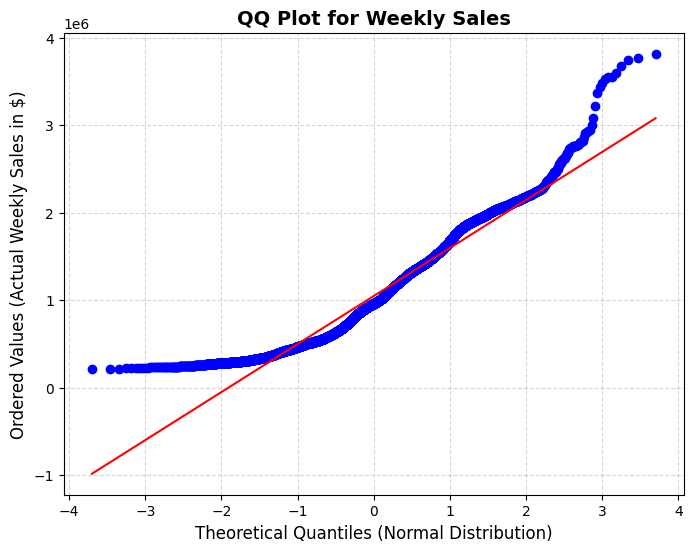

```python
import scipy.stats as stats
plt.figure(figsize=(8, 6))

stats.probplot(df['Weekly_Sales'], dist="norm", plot=plt)

# Customize labels and title for readability
plt.title('QQ Plot for Weekly Sales', fontsize=14, fontweight='bold')
plt.xlabel('Theoretical Quantiles (Normal Distribution)', fontsize=12)
plt.ylabel('Ordered Values (Actual Weekly Sales in $)', fontsize=12)
plt.grid(True, linestyle='--', alpha=0.5)

# Display the plot
plt.show()
```

```python
import scipy.stats as stats
from sklearn.linear_model import LinearRegression
from sklearn.preprocessing import StandardScaler

X = df[['CPI', 'Holiday_Flag', 'Temperature', 'Unemployment', 'Fuel_Price']]
y = df['Weekly_Sales']

scaler_X = StandardScaler()
scaler_y = StandardScaler()

X_scaled = scaler_X.fit_transform(X)
y_scaled = scaler_y.fit_transform(y.values.reshape(-1, 1)).flatten()

model = LinearRegression()
model.fit(X_scaled, y_scaled)
```

```
LinearRegression()
```

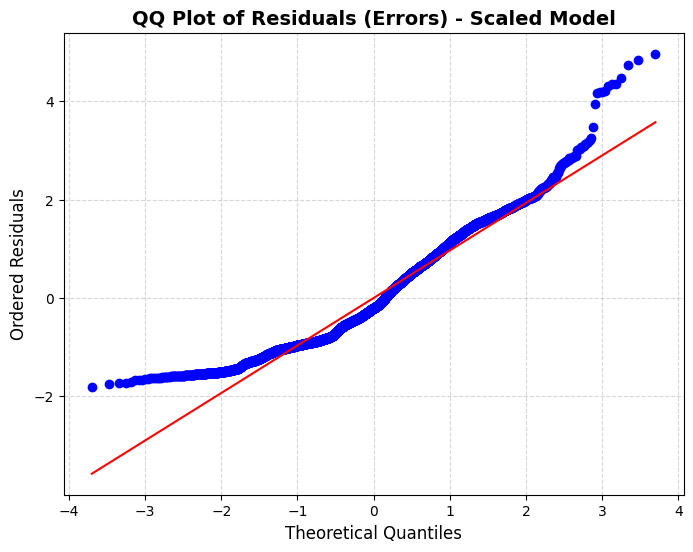

```python
y_pred_scaled = model.predict(X_scaled)
residuals = y_scaled - y_pred_scaled

plt.figure(figsize=(8, 6))
stats.probplot(residuals, dist="norm", plot=plt)

plt.title('QQ Plot of Residuals (Errors) - Scaled Model', fontsize=14, fontweight='bold')
plt.xlabel('Theoretical Quantiles', fontsize=12)
plt.ylabel('Ordered Residuals', fontsize=12)
plt.grid(True, linestyle='--', alpha=0.5)
plt.show()
```

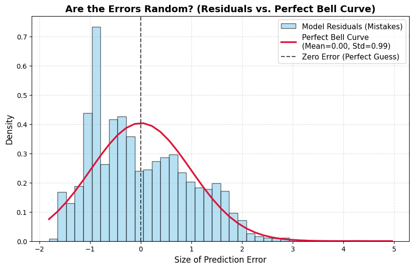

```python
import numpy as np
import matplotlib.pyplot as plt
import scipy.stats as stats

# Set the plot size
plt.figure(figsize=(10, 6))

# 1. Plot the histogram of your actual residuals
# 'density=True' converts counts to probabilities so the bell curve line fits perfectly
count, bins, ignored = plt.hist(residuals, bins=40, density=True, alpha=0.6,
                                color='skyblue', edgecolor='black', label='Model Residuals (Mistakes)')

# 2. Calculate the perfect theoretical bell curve based on your residuals
mu, sigma = residuals.mean(), residuals.std()
perfect_bell_curve = stats.norm.pdf(bins, mu, sigma)

# 3. Plot the perfect bell curve line
plt.plot(bins, perfect_bell_curve, color='crimson', linewidth=2.5,
         label=f'Perfect Bell Curve\n(Mean={mu:.2f}, Std={sigma:.2f})')

# 4. Add a vertical line at exactly 0 (where predictions would be perfect)
plt.axvline(0, color='black', linestyle='--', alpha=0.7, label='Zero Error (Perfect Guess)')

# 5. Customize titles and labels
plt.title('Are the Errors Random? (Residuals vs. Perfect Bell Curve)', fontsize=14, fontweight='bold')
plt.xlabel('Size of Prediction Error', fontsize=12)
plt.ylabel('Density', fontsize=12)
plt.legend(fontsize=11)
plt.grid(True, linestyle='--', alpha=0.4)

plt.show()
```